# Chi Squared Test

## Chi-Square Analysis on Location (Home/Road) vs. Wins/Losses:Indiana Fever

### Background

The goal of this analysis is to determine if the location of a game (Home vs. Road) influences the outcome (Win vs. Loss.) This analysis uses game data of the WNBA Indiana Fever to test whether the variables **Location** and **Outcome** are independent. The Data is retrieved from: https://stats.wnba.com/team/1611661325/traditional/

```r
location_wins <- matrix(c(11, 9, 9, 11), nrow = 2, byrow = TRUE)
colnames(location_wins) <- c("Wins", "Losses")
rownames(location_wins) <- c("Home", "Road")

location_df <- as.data.frame(as.table(location_wins))
colnames(location_df) <- c("Location", "Outcome", "Count")


print(location_wins)
```

```
##      Wins Losses
## Home   11      9
## Road    9     11
```

This contigency table tells us that the Indiana Fever won slightly more games at home than they lost and that they lost slightly more games on the road than they won. This shows the performance is fairly balanced between home and road games

### Hypotheses

**Null Hypothesis (𝐻0):** There is no association between Location (Home/Road) and Outcome (Win/Loss). The variables are independent.

**Alternative Hypothesis (𝐻𝑎):** There is an association between Location (Home/Road) and Outcome (Win/Loss).

### Graphical Summary

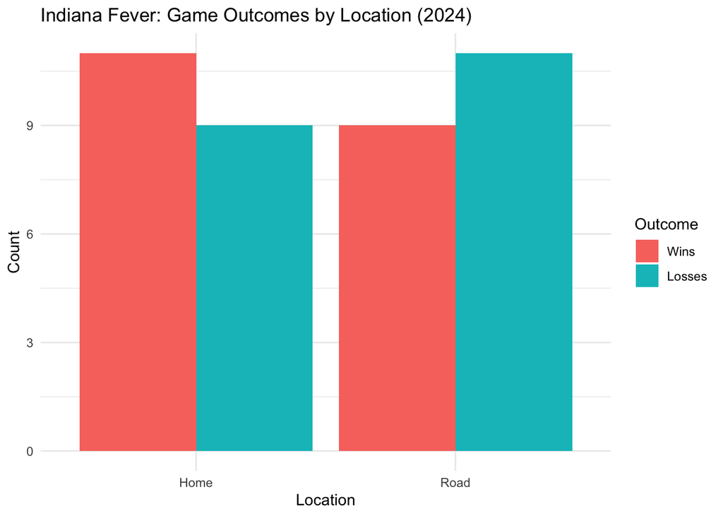

```r
library(ggplot2)

location_df <- as.data.frame(as.table(location_wins))
colnames(location_df) <- c("Location", "Outcome", "Count")

ggplot(location_df, aes(x = Location, y = Count, fill = Outcome)) +
  geom_bar(stat = "identity", position = "dodge") +
  labs(title = "Indiana Fever: Game Outcomes by Location (2024)",
       x = "Location",
       y = "Count",
       fill = "Outcome") +
  theme_minimal()
```

The bar plot visually confirms similar proportions of Wins/Losses for Home and Road games by visualizing the grouped bars for each outcome, differentiated by color.

### Chi-Square Analysis

```r
chi_result <- chisq.test(location_wins)
print(chi_result)
```

```
##
##  Pearson's Chi-squared test with Yates' continuity correction
##
## data:  location_wins
## X-squared = 0.1, df = 1, p-value = 0.7518
```

The high p-value indicates no statistically significant association between game location (Home/Road) and game outcomes (Wins/Losses).

Since p>0.05, we fail to reject the null hypothesis. There is no significant association between the playing location (Home/Road) and game outcomes (Wins/Losses).

### Checking requirements

```r
print(chi_result$expected)
```

```
##      Wins Losses
## Home   10     10
## Road   10     10
```

Expected counts are very close to the observed counts, indicating that the data aligns well with the null hypothesis of independence. If location were independent of outcome, we would expect 10 wins and 10 losses for both Home and Road games. The observed counts (11/9 and 9/11) are close to these expected values, suggesting no meaningful deviation.

Categorical Variables: The chi-squared test is used to analyze the relationship between two categorical variables (e.g., Location and Outcome).

The data must be in the form of counts or frequencies. It cannot be percentages, proportions, or continuous data.

The sample size must be large enough for the test to provide reliable results. This is assessed by examining the expected counts.

Observations (games) are independent: Each game belongs to only one category (Home or Road, Win or Loss).

**The analysis meets all the requirements for a valid chi-squared test. The results of the test (p-value = 0.7518) is reliable and valid for interpretation.**

### Chi-Square residuals

```r
print(chi_result$residuals)
```

```
##            Wins     Losses
## Home  0.3162278 -0.3162278
## Road -0.3162278  0.3162278
```

Residuals will be small because the observed values closely match the expected values. This reinforces the conclusion that the variables are independent.

### Conclusion

The analysis suggests that the location (Home/Road) does not significantly influence game outcomes (Wins/Losses) for the Indiana Fever during the 2024 season.

Coaching and strategy adjustments focused on location may not yield significant changes in performance.

The Fever’s success might depend more on other factors, such as player health, opposition strength, or in-game tactics, rather than home/road dynamics. These are all factors that can be explored in a future study.